# multiple_regression_tutorial_output.htm

Regression

NotesNotes, table, 0 levels of column headers and 2 levels of row headers, table with 3 columns and 20 rows

| Output Created |  | 02-MAR-2026 13:12:10 |
| --- | --- | --- |
| Comments |  |  |
| Input | Data | /Users/ovandef/webdev/github/sms/data/core_session.csv |
|  | Active Dataset | DataSet1 |
|  | Filter | time = "pre" (FILTER) |
|  | Weight | <none> |
|  | Split File | <none> |
|  | N of Rows in Working Data File | 60 |
| Missing Value Handling | Definition of Missing | User-defined missing values are treated as missing. |
|  | Cases Used | Statistics are based on cases with no missing values for any variable used. |
| Syntax |  | REGRESSION /DESCRIPTIVES MEAN STDDEV CORR SIG N /MISSING LISTWISE /STATISTICS COEFF OUTS CI(95) R ANOVA ZPP TOL /CRITERIA=PIN(.05) POUT(.10) /NOORIGIN /DEPENDENT sprint_20m_s /METHOD=ENTER vo2_mlkgmin… |
| Resources | Processor Time | 00:00:00.55 |
|  | Elapsed Time | 00:00:00.00 |
|  | Memory Required | 3504 bytes |
|  | Additional Memory Required for Residual Plots | 536 bytes |
| Variables Created or Modified | PRE_1 | Unstandardized Predicted Value |
|  | ZPR_1 | Standardized Predicted Value |
|  | ZRE_1 | Standardized Residual |
|  | COO_1 | Cook's Distance |

Descriptive Statistics

|  | Mean | Std. Deviation | N |
| --- | --- | --- | --- |
| sprint_20m_s | 3.79138 | .354344 | 60 |
| vo2_mlkgmin | 41.340 | 6.8174 | 60 |
| strength_kg | 78.005 | 12.9977 | 60 |

Correlations

|  |  | sprint_20m_s | vo2_mlkgmin | strength_kg |
| --- | --- | --- | --- | --- |
| Pearson Correlation | sprint_20m_s | 1.000 | -.643 | -.665 |
|  | vo2_mlkgmin | -.643 | 1.000 | .603 |
|  | strength_kg | -.665 | .603 | 1.000 |
| Sig. (1-tailed) | sprint_20m_s | . | <.001 | <.001 |
|  | vo2_mlkgmin | .000 | . | .000 |
|  | strength_kg | .000 | .000 | . |
| N | sprint_20m_s | 60 | 60 | 60 |
|  | vo2_mlkgmin | 60 | 60 | 60 |
|  | strength_kg | 60 | 60 | 60 |

**Pearson Correlation**  
██ **Highly Positive:** *(None)*  
██ **Positive:** *(vo2_mlkgmin <---> strength_kg)*  
██ **No Linear Correlation:** *(None)*  
██ **Negative:** *(sprint_20m_s <---> vo2_mlkgmin), (sprint_20m_s <---> strength_kg)*  
██ **Highly Negative:** *(None)*  
*Note: Curated Help is calculated based on actual cell values, not the formatted values.*

Variables Entered/Removed<sup>a</sup>

| Model | Variables Entered | Variables Removed | Method |
| --- | --- | --- | --- |
| 1 | strength_kg, vo2_mlkgmin<sup>b</sup> | . | Enter |

a. Dependent Variable: sprint_20m_s  
b. All requested variables entered.

Model Summary<sup>b</sup>

| Model | R | R Square | Adjusted R Square | Std. Error of the Estimate |
| --- | --- | --- | --- | --- |
| 1 | .731<sup>a</sup> | .535 | .518 | .245932 |

a. Predictors: (Constant), strength_kg, vo2_mlkgmin  
b. Dependent Variable: sprint_20m_s

ANOVA<sup>a</sup>

| Model |  | Sum of Squares | df | Mean Square | F | Sig. |
| --- | --- | --- | --- | --- | --- | --- |
| 1 | Regression | 3.961 | 2 | 1.980 | 32.741 | <.001<sup>b</sup> |
|  | Residual | 3.448 | 57 | .060 |  |  |
|  | Total | 7.408 | 59 |  |  |  |

a. Dependent Variable: sprint_20m_s  
b. Predictors: (Constant), strength_kg, vo2_mlkgmin

Coefficients<sup>a</sup>

| Model | Model | Unstandardized Coefficients B | Unstandardized Coefficients Std. Error | Standardized Coefficients Beta | t | Sig. | 95.0% Confidence Interval for B Lower Bound | 95.0% Confidence Interval for B Upper Bound | Correlations Zero-order | Correlations Partial | Correlations Part | Collinearity Statistics Tolerance | VIF |
| --- | --- | --- | --- | --- | --- | --- | --- | --- | --- | --- | --- | --- | --- |
| 1 | (Constant) | 5.536 | .218 |  | 25.382 | <.001 | 5.099 | 5.973 |  |  |  |  |  |
|  | vo2_mlkgmin | -.020 | .006 | -.381 | -3.365 | .001 | -.032 | -.008 | -.643 | -.407 | -.304 | .637 | 1.570 |
|  | strength_kg | -.012 | .003 | -.435 | -3.844 | <.001 | -.018 | -.006 | -.665 | -.454 | -.347 | .637 | 1.570 |

a. Dependent Variable: sprint_20m_s

**Correlations Zero-order**  
██ **Highly Positive:** *(None)*  
██ **Positive:** *(None)*  
██ **No Linear Correlation:** *(None)*  
██ **Negative:** *(vo2_mlkgmin <---> Model 1), (strength_kg <---> Model 1)*  
██ **Highly Negative:** *(None)*  
**Correlations Partial**  
██ **Highly Positive:** *(None)*  
██ **Positive:** *(None)*  
██ **No Linear Correlation:** *(None)*  
██ **Negative:** *(vo2_mlkgmin <---> Model 1), (strength_kg <---> Model 1)*  
██ **Highly Negative:** *(None)*  
**Correlations Part**  
██ **Highly Positive:** *(None)*  
██ **Positive:** *(None)*  
██ **No Linear Correlation:** *(None)*  
██ **Negative:** *(vo2_mlkgmin <---> Model 1), (strength_kg <---> Model 1)*  
██ **Highly Negative:** *(None)*  
*Note: Curated Help is calculated based on actual cell values, not the formatted values.*

Residuals Statistics<sup>a</sup>

|  | Minimum | Maximum | Mean | Std. Deviation | N |
| --- | --- | --- | --- | --- | --- |
| Predicted Value | 3.22235 | 4.30703 | 3.79138 | .259090 | 60 |
| Std. Predicted Value | -2.196 | 1.990 | .000 | 1.000 | 60 |
| Standard Error of Predicted Value | .032 | .093 | .053 | .015 | 60 |
| Adjusted Predicted Value | 3.18785 | 4.37528 | 3.79248 | .261902 | 60 |
| Residual | -.530274 | .539911 | .000000 | .241728 | 60 |
| Std. Residual | -2.156 | 2.195 | .000 | .983 | 60 |
| Stud. Residual | -2.217 | 2.317 | -.002 | 1.013 | 60 |
| Deleted Residual | -.560820 | .601153 | -.001092 | .256935 | 60 |
| Stud. Deleted Residual | -2.299 | 2.412 | -.004 | 1.028 | 60 |
| Mahal. Distance | .003 | 7.508 | 1.967 | 1.714 | 60 |
| Cook's Distance | .000 | .203 | .021 | .039 | 60 |
| Centered Leverage Value | .000 | .127 | .033 | .029 | 60 |

a. Dependent Variable: sprint_20m_s

Charts

*zresid Normal P-P Plot

Normal P-P Plot of Regression Standardized Residual

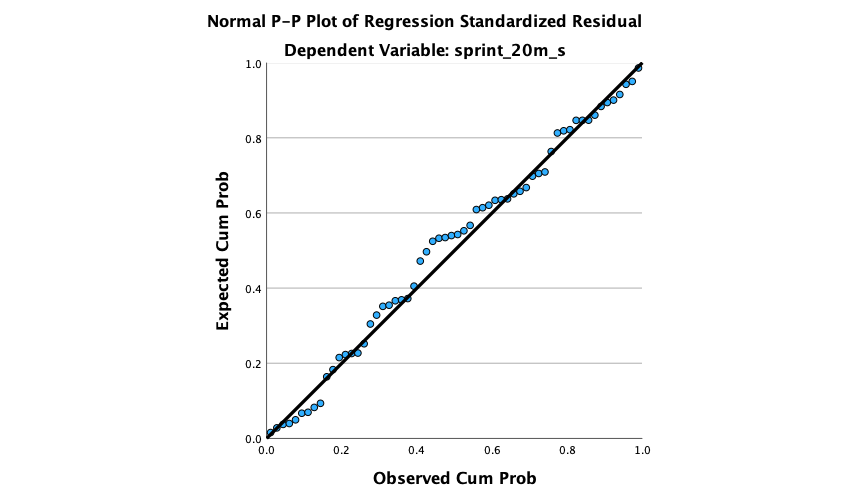

*zresid by *zpred Scatterplot

Scatterplot

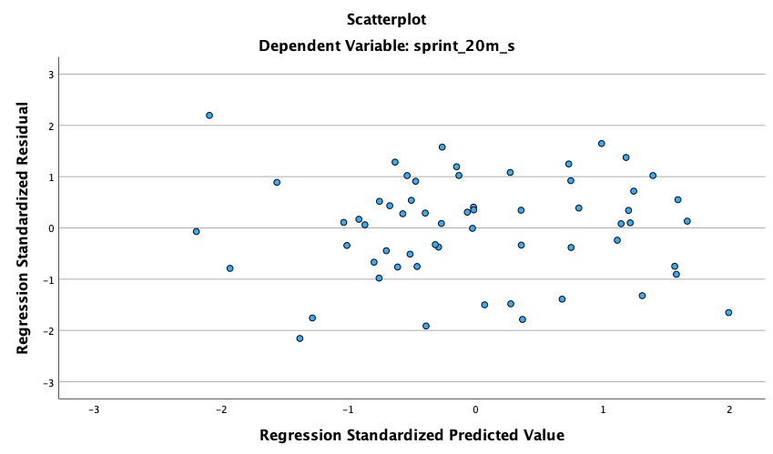